# Homework 3

Ziyang (Bob) Ding

08 February, 2020

## Problem 1

**For a sample $\left(Y_{1}, \ldots, Y_{n}\right)$ from $g,$ define weights**
$$\begin{aligned}
w_{i}=\frac{\pi\left(Y_{i}\right) / g\left(Y_{i}\right)}{\sum_{j=1}^{n} \pi\left(Y_{j}\right) / g\left(Y_{j}\right)}
\end{aligned}$$

**The sampling importance-resampling (SIR) algorithm (Rubin 1987 ) proceeds as follows:For $j=1, \ldots, m,$ take $X_{j}=Y_{i}$ with probability $w_{i}$**

**(b) What if the algorithm is modified to sample without replacement?**

**Proof**

First, assume that we are doing replacements. In this way
$$X_j \sim \{Y_1, Y_2 \dots Y_n\} \quad \mathbb{P}(X_j= Y_i) = w_i$$
Therefore, the pdf $X_j$ has support on $\{Y_1, Y_2 \dots Y_n\}$. Then, because we know that
$$\sum w_{i}= \sum \frac{\pi\left(Y_{i}\right) / g\left(Y_{i}\right)}{\sum_{j=1}^{n} \pi\left(Y_{j}\right) / g\left(Y_{j}\right)} = 1$$
This let us know that when $m \to \infty$, we have that
$$\begin{aligned}
\frac{1}{m} \sum_{j=1}^{m} h\left(x_{j}\right) \rightarrow \mathbb{E}(h(x))&=\sum_{i=1}^{n} h\left(Y_{i}\right) \cdot W_{i} =\sum_{i=1}^{n} h\left(Y_{i}\right) \cdot \frac{\pi\left(Y_{i}\right) / g\left(Y_{i}\right)}{\sum \pi\left(Y_{i}\right) / g\left(Y_{i}\right)}\\
&=\frac{\sum_{i=1}^{n} h\left(Y_{i}\right) \cdot \pi\left(Y_{i}\right) / g\left(Y_{i}\right)}{\sum_{i=1}^{n} \pi\left(Y_{i}\right) / g\left(Y_{i}\right)}=\frac{\sum_{i=1}^{n} h\left(Y_{i}\right) \cdot \omega_{i}^{'}}{\sum \omega_{i}^{'}}
\end{aligned}$$
We can observe that this is a normalized Importance Sampler. And
$$\frac{\sum_{i=1}^{n} h\left(Y_{i}\right) \cdot w_{i}^{\prime}}{\sum w_{i}^{\prime}} \rightarrow \mathbb{E}(h(Y))$$
Therefore, this is an asymptotically unbiased (consistent) estimator, which equivalent to the IS estimator.

If sample without replacement, then $x$ will not follow a discrete distribution taking values $\left\{Y_{1}, Y_{2}, \ldots Y_{n}\right\}$ with probability $\left\{w_{1}, w_{2}, \cdots, w_{n}\right\}$ Instead, $X$ will have the same distribution as $Y,$ i.e. $X \sim g(X)$ Then $\frac{1}{m} \sum_{j=1}^{m} h\left(x_{j}\right)$ will be an estimate of $h(x)$ under $x \sim g(x)$.

```r
n <- 100000; m <- 100000
# SIR with replacement
Y <- runif(n, 0, 1)
pi <- dbeta(Y,2,5)
g <- dunif(Y,0,1)
W <- (pi/g)/(sum(pi/g))
X <- sample(Y, m, replace = TRUE, prob = W)
mean(X<0.5)
```

```
## [1] 0.89097
```

```r
# SIR without replacement
Y <- runif(n, 0, 1)
pi <- dbeta(Y,2,5)
g <- dunif(Y,0,1)
W <- (pi/g)/(sum(pi/g))
X <- sample(Y, m, replace = FALSE, prob = W)
mean(X<0.5)
```

```
## [1] 0.50022
```

As we can see the difference between replacement and not no replacement.

## Problem 2

**Estimate the mean and variance of a $N(0,1)$ target distribution using importance sampling with instrumental distribution $t_{\nu}(0,1) .$ Plot your estimates as a function of sample size. Compare results for several values of $\nu$**

**Now repeat with $t_{\nu}$ as the target, and $N(0,1)$ as the approximating distribution. What do you observe? Relate your observations to the theoretical properties discussed in class.**

**Proof**

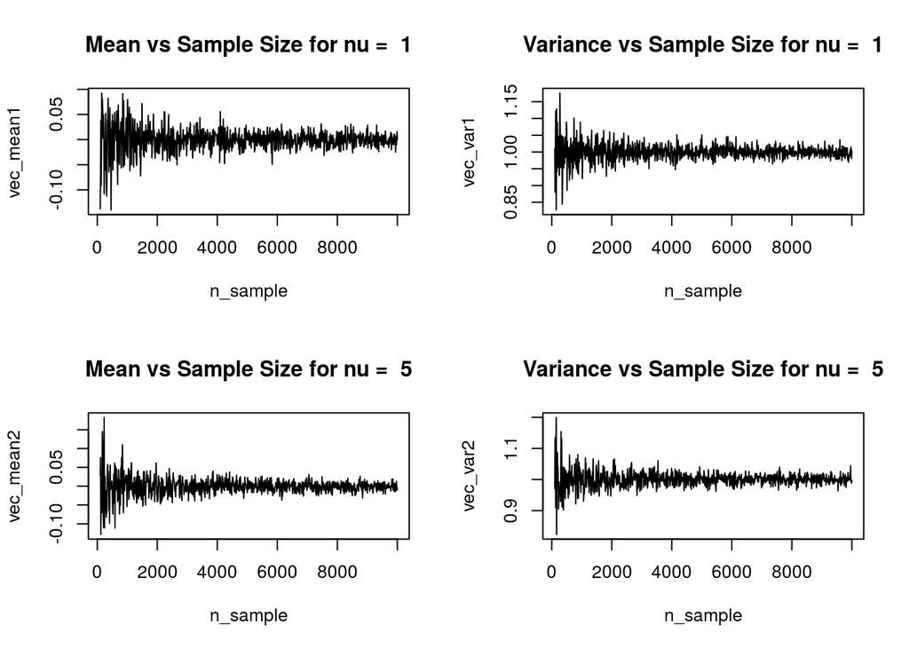

```r
set.seed(1)
ImpSample <- function(s, nu){
x <- rt(s, nu)
w <- dnorm(x, 0, 1) / dt(x, nu)
mean <- mean(w * x)
var <- mean(w * x^2) - mean^2
return(c(mean, var))
}
RunAll <- function(nu1, nu2){
n_sample <- seq(100, 10000, 10)
vec_mean1 <- vec_var1 <- rep(NA, length(n_sample))
for(i in 1:length(n_sample)){
output <- ImpSample(n_sample[i], nu1)
vec_mean1[i] <- output[1]
vec_var1[i] <- output[2]
}
vec_mean2 <- vec_var2 <- rep(NA, length(n_sample))
for(i in 1:length(n_sample)){
output <- ImpSample(n_sample[i], nu2)
vec_mean2[i] <- output[1]
vec_var2[i] <- output[2]
}
par(mfrow=c(2,2))
plot(n_sample, vec_mean1, type = "l", main = paste("Mean vs Sample Size for nu = ",nu1))
plot(n_sample, vec_var1, type = "l", main = paste("Variance vs Sample Size for nu = ",nu1))
plot(n_sample, vec_mean2, type = "l", main = paste("Mean vs Sample Size for nu = ",nu2))
plot(n_sample, vec_var2, type = "l", main = paste("Variance vs Sample Size for nu = ",nu2))
}
# Run for different nu
RunAll(1, 5)
```

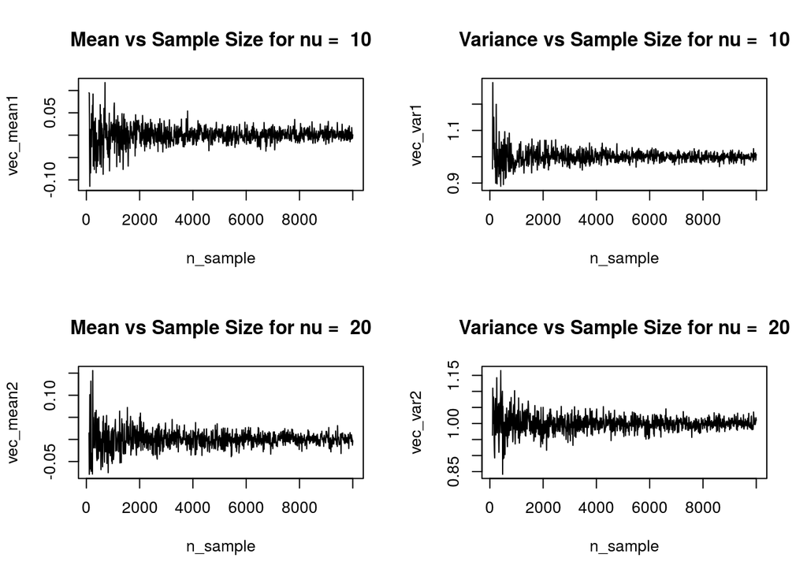

```r
RunAll(10, 20)
```

**Similarity**

Noticablly, because $t_{\nu}$ distribution and normal distribution have similar density, we see that no matter what $\nu$ is, the sampling shows that an increasing sample size will help convergence of mean and variance to the correct value.

**Differnce**

Well, as $\nu$ increases, the variance of the estimators does not seem to vary much, so it’s not sensitive to value of $\nu$. I think when $\nu$ become too big will cause a problem. But within a given range, the importance sampling should be fine. Sensitivity is not very high.

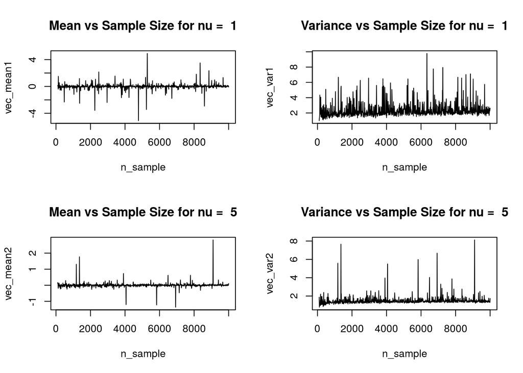

```r
set.seed(1)
ImpSample <- function(s, nu){
x <- rnorm(s, 0, 1)
w <- dt(x, nu) / dnorm(x, 0, 1)
mean <- sum(w * x) / sum(w)
var <- sum(w * x^2) / sum(w) - mean^2
return(c(mean, var))
}
RunAll <- function(nu1, nu2){
n_sample <- seq(100, 10000, 10)
vec_mean1 <- vec_var1 <- rep(NA, length(n_sample))
for(i in 1:length(n_sample)){
output <- ImpSample(n_sample[i], nu1)
vec_mean1[i] <- output[1]
vec_var1[i] <- output[2]
}
vec_mean2 <- vec_var2 <- rep(NA, length(n_sample))
for(i in 1:length(n_sample)){
output <- ImpSample(n_sample[i], nu2)
vec_mean2[i] <- output[1]
vec_var2[i] <- output[2]
}
par(mfrow=c(2,2))
plot(n_sample, vec_mean1, type = "l", main = paste("Mean vs Sample Size for nu = ",nu1))
plot(n_sample, vec_var1, type = "l", main = paste("Variance vs Sample Size for nu = ",nu1))
plot(n_sample, vec_mean2, type = "l", main = paste("Mean vs Sample Size for nu = ",nu2))
plot(n_sample, vec_var2, type = "l", main = paste("Variance vs Sample Size for nu = ",nu2))
}
# Run for different nu
RunAll(1, 5)
```

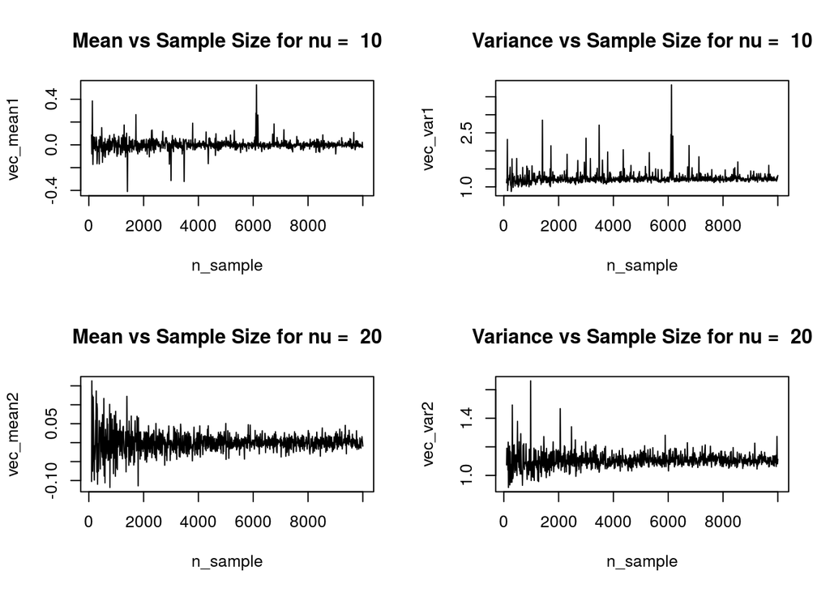

```r
RunAll(10, 20)
```

**Similarity**

**Difference**

This time, we can see that as $\nu$ increases, the variances of estimators reduces. This is because as $\nu$ increases, the tail got lower and approximatly converge in distribution to a normal distribution. In this way, sampling procedure is more and more concentrated, and importance is more heavily sampled, which reduces variance of target estimator.

## Problem 3

**Show that if $X, Z \stackrel{\text { ind }}{\sim} U[0,1]$ and $Y=1 / Z,$ then $\operatorname{var}(X / Y)<\infty .$ Compare this with the variance obtained by the delta method. How do you account for the difference?**

**Proof**

- Delta method:

Detta Method: since $\sigma_{XZ}=0, \quad$ use lst order approximation:
$$\operatorname{var}\left(\frac{X}{Y}\right)=\operatorname{var}(XZ)=\sigma_{X}^{2} \cdot M_{X}^{2}+\sigma_{Z}^{2} \cdot \mu_{Z}^{2}+2 \cdot 0=\frac{1}{12} \cdot\left(\frac{1}{2}\right)^{2}+\frac{1}{12} \cdot\left(\frac{1}{2}\right)^{2}=\frac{1}{24}$$

- This method:

$\quad \mathbb{E}(X)=\frac{1}{2}, \quad \operatorname{var}(X)=\operatorname{var}(Z)=\frac{1}{12} \cdot \mathbb{E}\left(X^{2}\right)=\mathbb{E}\left(Z^{2}\right)=\frac{1}{12}+\left(\frac{1}{2}\right)^{2}=\frac{1}{3}$

$$\begin{align*}
\begin{aligned}
\operatorname{var}\left(\frac{X}{Y}\right) &=\operatorname{var}(XZ)=\mathbb{E}\left((XZ)^{2}\right)-\mathbb{E}(XZ)^{2}=\mathbb{E}\left(X^{2}\right)-\mathbb{E}(X)^{2} \cdot\left[E\left(Z^{2}\right)\right]\\
&=\frac{1}{3} \cdot \frac{1}{3}-\left(\frac{1}{2}\right)^{4}=\frac{1}{9}-\frac{1}{16}=\frac{7}{144}
\end{aligned}
\end{align*}$$

note that $\frac{7}{144}>\frac{1}{24}$. If we could increase the order to maybe 3,5$\dots$, it delta would be even better.